# Propensity Score Adjustment in ForestSearch: Complete Workflow

IPTW vs. DR G-Computation — Implementation, Theory, and Simulation Evaluation

Author

Larry F. León

Published

March 25, 2026

```r
devtools::document(quiet = TRUE)
devtools::load_all(".", quiet = TRUE)
source("dev/glm/glm_effect_estimators.R")

suppressPackageStartupMessages({
  library(survival)
  library(data.table)
  library(grf)
  library(glmnet)
  library(gt)
  library(ggplot2)
})
theme_set(theme_minimal(base_size = 12))
```

# 1 Methodology

## 1.1 Two Approaches to PS Adjustment

ForestSearch offers two PS adjustment methods for GLM effect estimation in observational studies. Both use propensity scores estimated on the full sample; they differ in **how** the PS enters the outcome model.

### 1.1.1 Option A: Stabilized IPTW (Default)

Inverse probability of treatment weighting creates a pseudo-population where treatment is independent of measured confounders. Stabilized weights are:

$$\text{sw}_i = \begin{cases}
P(W=1) / \hat{e}(X_i) & \text{if } W_i = 1 \\
P(W=0) / (1 - \hat{e}(X_i)) & \text{if } W_i = 0
\end{cases}$$

The outcome model is simply `glm(Y ~ treat, weights = sw, ...)`. The treatment coefficient **is** the marginal causal effect — no post-processing required.

### 1.1.2 Option B: Bang & Robins (2005) DR G-Computation

The doubly-robust approach from Section 2.2 of Bang & Robins (2005) adds the inverse probability of treatment received as a covariate:

$$\frac{1}{f(W_i \mid V; \hat\alpha)} = \begin{cases}
1 / \hat{e}(X_i) & \text{if } W_i = 1 \\
1 / (1 - \hat{e}(X_i)) & \text{if } W_i = 0
\end{cases}$$

The outcome model is `glm(Y ~ treat + ips_covar, ...)`.

**Critically**, for non-identity links (logit, log), the treatment coefficient $\hat\beta_1$ is **not** the DR treatment effect. Section 2.2 of Bang & Robins (2005) specifies:

$$\hat\mu_{dr} = n^{-1} \sum_i \bigl[e(1, V_i; \hat\beta, \hat\phi) -
e(0, V_i; \hat\beta, \hat\phi)\bigr]$$

This requires **G-computation**: predicting under both counterfactual treatment assignments, with the IPS covariate set to its correct value under each assignment ($1/\hat{e}(X)$ for $W=1$, $1/(1-\hat{e}(X))$ for $W=0$), then averaging the contrast.

### 1.1.3 Key Theoretical Distinction

The DR property requires that the outcome model `s(W, V; beta)` contain **confounders**. If either the PS model or the outcome model for $E(Y \mid W, V)$ is correctly specified, the estimator is consistent.

ForestSearch’s estimator closures intentionally use **treatment-only outcome models** within subgroup slices (no confounders in the outcome model). This means:

- **IPTW**: Works correctly. The weights create a pseudo-population; no confounders needed in the outcome model.
- **DR G-comp**: Loses its doubly-robust property because confounders are omitted from the outcome model. Reduces to a misspecified regression with the IPS covariate, which has no theoretical guarantee.

This document demonstrates this distinction empirically.

## 1.2 Comparison Summary

| Property | IPTW (Option A) | DR G-comp (Option B) |
| --- | --- | --- |
| **Model** | `glm(Y ~ treat, weights = sw)` | `glm(Y ~ treat + ips_covar)` + G-comp |
| **Coefficient** | IS the effect | Requires G-computation |
| **Requires confounders in outcome model?** | No | Yes (for DR property) |
| **Works with ForestSearch’s treatment-only models?** | **Yes** | **No** |
| **Extreme PS sensitivity** | Moderate (stabilized) | Low (covariate) |
| **Reference** | Hernán & Robins (2020) | Bang & Robins (2005), §2.2 |

# 2 Complete Workflow

## 2.1 Stage 1: GRF Screening (Internal PS)

When `use_grf = TRUE`, GRF fits `causal_forest(X, Y, W)` which internally estimates $\hat{e}(X_i) = E[W_i \mid X_i]$ via `regression_forest(X, W)`. These out-of-bag, cross-fitted propensity scores are used within GRF for CATE estimation only — they do **not** affect downstream effect estimates.

## 2.2 Stage 2: PS Estimation for Effect Adjustment

**Location:** `forestsearch_main.R`, Section 2C

After outcome type is resolved (Section 2B), ForestSearch optionally estimates propensity scores on the **full `df.analysis`**.

```
forestsearch(..., ps_method = "grf", ps_adjust_method = "iptw")
     ↓
  Section 2C: estimate_propensity_scores()
     ├── Estimate e(X) on full sample
     ├── Trim PS to [2.5%, 97.5%]
     ├── Compute stabilized weights: sw = P(W)/e(X) or P(1-W)/(1-e(X))
     ├── Compute IPS covariate:       1/e(X) or 1/(1-e(X))
     ├── Add ps_hat, sw, ips_covar columns to df.analysis
     └── Rebuild estimator closure:
           make_effect_estimator(..., ps_adjust_method = "iptw")
```

**Default behavior:**

| Setting | `ps_method` | `ps_adjust_method` | Rationale |
| --- | --- | --- | --- |
| `is.RCT = TRUE` | `"none"` | N/A | Randomization ensures balance |
| `is.RCT = FALSE` | `"grf"` | `"iptw"` | Non-parametric PS, stabilized weights |
| User-supplied | `ps_hat = vec` | `"iptw"` | Maximum flexibility |

## 2.3 Stage 3: Subgroup Search

The estimator closure is called on each candidate subgroup slice. For IPTW, the stabilized weights computed on the full sample are carried into each slice. The weights are **never re-estimated** within subgroup slices.

## 2.4 Stage 4: Bootstrap

Bootstrap re-enters Section 2C on resampled data. The full estimation procedure (PS estimation → weight computation → estimator rebuild) is replicated from scratch on each bootstrap sample.

# 3 PS Estimation Methods

```r
df <- survival::gbsg
df$id <- seq_len(nrow(df))
df$grade3 <- as.integer(df$grade == "3")
confs <- c("age", "meno", "size", "grade3", "nodes", "pgr", "er")

ps_grf   <- estimate_propensity_scores(df, "hormon", confs, method = "grf")
ps_lasso <- estimate_propensity_scores(df, "hormon", confs, method = "lasso")
ps_logit <- estimate_propensity_scores(df, "hormon", confs, method = "logistic")

ps_compare <- data.frame(
  Method  = c("GRF", "LASSO", "Logistic"),
  Mean    = round(c(mean(ps_grf$ps_hat), mean(ps_lasso$ps_hat),
                     mean(ps_logit$ps_hat)), 3),
  SD      = round(c(sd(ps_grf$ps_hat), sd(ps_lasso$ps_hat),
                     sd(ps_logit$ps_hat)), 3),
  Min     = round(c(min(ps_grf$ps_hat), min(ps_lasso$ps_hat),
                     min(ps_logit$ps_hat)), 3),
  Max     = round(c(max(ps_grf$ps_hat), max(ps_lasso$ps_hat),
                     max(ps_logit$ps_hat)), 3),
  Trimmed = c(ps_grf$trimmed, ps_lasso$trimmed, ps_logit$trimmed),
  Cor_GRF = round(c(1, cor(ps_grf$ps_hat, ps_lasso$ps_hat),
                     cor(ps_grf$ps_hat, ps_logit$ps_hat)), 3)
)
gt(ps_compare) |>
  tab_header(title = md("**PS Estimation Methods on GBSG Data**"),
             subtitle = "P(hormon = 1 | X)") |>
  cols_label(Cor_GRF = "Cor with GRF")
```

**PS Estimation Methods on GBSG Data**

P(hormon = 1 | X)

| Method | Mean | SD | Min | Max | Trimmed | Cor with GRF |
| --- | --- | --- | --- | --- | --- | --- |
| GRF | 0.359 | 0.117 | 0.178 | 0.573 | 0 | 1.000 |
| LASSO | 0.359 | 0.121 | 0.151 | 0.654 | 0 | 0.955 |
| Logistic | 0.359 | 0.143 | 0.133 | 0.814 | 0 | 0.947 |

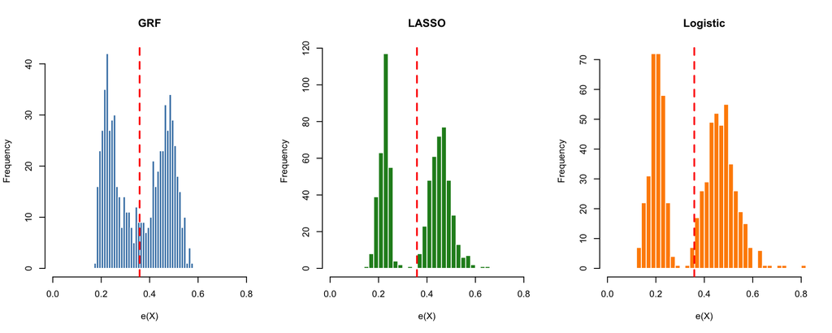

```r
par(mfrow = c(1, 3))
hist(ps_grf$ps_hat, breaks = 30, col = "steelblue", border = "white",
     main = "GRF", xlab = "e(X)", xlim = c(0, 0.8))
abline(v = mean(df$hormon), col = "red", lwd = 2, lty = 2)
hist(ps_lasso$ps_hat, breaks = 30, col = "forestgreen", border = "white",
     main = "LASSO", xlab = "e(X)", xlim = c(0, 0.8))
abline(v = mean(df$hormon), col = "red", lwd = 2, lty = 2)
hist(ps_logit$ps_hat, breaks = 30, col = "darkorange", border = "white",
     main = "Logistic", xlab = "e(X)", xlim = c(0, 0.8))
abline(v = mean(df$hormon), col = "red", lwd = 2, lty = 2)
```

```r
par(mfrow = c(1, 1))
```

# 4 Simulation Study

## 4.1 Data-Generating Mechanism

```r
simulate_obs_study <- function(
    n = 2000, seed = 42L,
    confounding_strength = 1.0,
    subgroup_effect = 0.8,       # log-OR in subgroup (harm)
    complement_effect = -0.4,    # log-OR in complement (benefit)
    prognostic_strength = 0.5,
    n_noise = 3
) {
  set.seed(seed)

  x1 <- rbinom(n, 1, 0.5)       # subgroup definer
  x2 <- rbinom(n, 1, 0.4)       # noise binary
  x3 <- rnorm(n)                 # confounder (treatment AND outcome)
  x4 <- rnorm(n)                 # prognostic only
  noise <- matrix(rnorm(n * n_noise), n, n_noise)
  colnames(noise) <- paste0("noise", seq_len(n_noise))

  # Confounded treatment: depends on x1 and x3
  lp_treat <- -0.5 + confounding_strength *
    (0.6 * x1 + 0.8 * x3 + 0.2 * x1 * x3)
  ps_true <- plogis(lp_treat)
  treat <- rbinom(n, 1, ps_true)

  in_sg <- x1 == 1

  # Outcome: x3 is a prognostic confounder
  lp_outcome <- -1.0 +
    prognostic_strength * x3 +
    0.3 * x4 +
    ifelse(in_sg, subgroup_effect, complement_effect) * treat
  event <- rbinom(n, 1, plogis(lp_outcome))

  tte <- rexp(n, rate = 0.05) + 1

  df <- data.frame(
    id = seq_len(n), x1 = x1, x2 = x2, x3 = x3, x4 = x4,
    treat = treat, event = event, tte = tte,
    in_sg = in_sg, ps_true = ps_true
  )
  cbind(df, noise)
}
```

## 4.2 Scenario Definitions

Seven scenarios spanning moderate to extreme confounding, weak to strong signals, sparse to dense covariate spaces, and a small-sample stress test.

```r
scenarios <- list(
  A = list(
    name = "Moderate confounding",
    confounding_strength = 0.8, subgroup_effect = 0.8,
    complement_effect = -0.4, prognostic_strength = 0.5, n_noise = 3
  ),
  B = list(
    name = "Strong confounding",
    confounding_strength = 1.5, subgroup_effect = 0.8,
    complement_effect = -0.4, prognostic_strength = 0.8, n_noise = 3
  ),
  C = list(
    name = "Very strong confounding + weak signal",
    confounding_strength = 2.0, subgroup_effect = 0.5,
    complement_effect = -0.2, prognostic_strength = 1.0, n_noise = 3
  ),
  D = list(
    name = "Strong confounding + many noise covariates",
    confounding_strength = 1.5, subgroup_effect = 0.8,
    complement_effect = -0.4, prognostic_strength = 0.8, n_noise = 10
  ),
  E = list(
    name = "No confounding (RCT benchmark)",
    confounding_strength = 0.0, subgroup_effect = 0.8,
    complement_effect = -0.4, prognostic_strength = 0.5, n_noise = 3
  ),
  F_ = list(
    name = "Extreme confounding + strong signal",
    confounding_strength = 2.5, subgroup_effect = 1.2,
    complement_effect = -0.6, prognostic_strength = 1.2, n_noise = 3
  ),
  G = list(
    name = "Moderate confounding + small N",
    confounding_strength = 1.0, subgroup_effect = 0.8,
    complement_effect = -0.4, prognostic_strength = 0.5, n_noise = 3
  )
)
```

## 4.3 Monte Carlo Evaluation

Each scenario is evaluated with 200 Monte Carlo replications (N = 2000 per simulation, except Scenario G which uses N = 500).

Four estimators are compared:

1. **Unadjusted**: `glm(event ~ treat, family = binomial)`.
2. **IPTW (GRF PS)**: Stabilized weights from GRF-estimated PS.
3. **DR G-comp (GRF PS)**: Bang & Robins IPS covariate + G-computation.
4. **IPTW (Oracle PS)**: Stabilized weights from the true PS (benchmark).

```r
n_sims <- 200

confs_sim <- c("x1", "x2", "x3", "x4")

run_mc <- function(scenario, n_sims, n_per_sim = 2000) {
  results <- data.frame(
    sim = integer(), method = character(),
    sg_est = numeric(), co_est = numeric(),
    stringsAsFactors = FALSE
  )

  all_confs <- c(confs_sim, paste0("noise", seq_len(scenario$n_noise)))

  fn_none <- make_effect_estimator("binary", "treat", "event",
    effect_measure = "OR", ps_adjust_method = "none")
  fn_iptw <- make_effect_estimator("binary", "treat", "event",
    effect_measure = "OR", ps_adjust_method = "iptw")
  fn_dr   <- make_effect_estimator("binary", "treat", "event",
    effect_measure = "OR", ps_adjust_method = "dr_gcomp")

  for (s in seq_len(n_sims)) {
    df_s <- simulate_obs_study(
      n = n_per_sim, seed = s,
      confounding_strength  = scenario$confounding_strength,
      subgroup_effect       = scenario$subgroup_effect,
      complement_effect     = scenario$complement_effect,
      prognostic_strength   = scenario$prognostic_strength,
      n_noise               = scenario$n_noise
    )

    ps_s <- estimate_propensity_scores(df_s, "treat", all_confs, method = "grf")
    df_s <- ps_s$data

    # Oracle IPTW weights
    p_treat <- mean(df_s$treat)
    df_s$sw_oracle <- ifelse(
      df_s$treat == 1,
      p_treat / df_s$ps_true,
      (1 - p_treat) / (1 - df_s$ps_true))

    sg <- df_s[df_s$x1 == 1, ]
    co <- df_s[df_s$x1 == 0, ]

    sg_orac <- sg; sg_orac$sw <- sg_orac$sw_oracle
    co_orac <- co; co_orac$sw <- co_orac$sw_oracle

    results <- rbind(results,
      data.frame(sim = s, method = "1. Unadjusted",
        sg_est = fn_none(sg)$estimate, co_est = fn_none(co)$estimate),
      data.frame(sim = s, method = "2. IPTW (GRF PS)",
        sg_est = fn_iptw(sg)$estimate, co_est = fn_iptw(co)$estimate),
      data.frame(sim = s, method = "3. DR G-comp (GRF PS)",
        sg_est = fn_dr(sg)$estimate, co_est = fn_dr(co)$estimate),
      data.frame(sim = s, method = "4. IPTW (Oracle PS)",
        sg_est = fn_iptw(sg_orac)$estimate, co_est = fn_iptw(co_orac)$estimate)
    )
  }
  results
}

all_results <- list()
for (sc_name in names(scenarios)) {
  sc <- scenarios[[sc_name]]
  cat("Running scenario", sc_name, ":", sc$name, "...\n")
  n_per <- if (sc_name == "G") 500 else 2000
  all_results[[sc_name]] <- run_mc(sc, n_sims, n_per_sim = n_per)
}
```

```
#> Running scenario A : Moderate confounding ...
```

```
#> Running scenario B : Strong confounding ...
```

```
#> Running scenario C : Very strong confounding + weak signal ...
```

```
#> Running scenario D : Strong confounding + many noise covariates ...
```

```
#> Running scenario E : No confounding (RCT benchmark) ...
```

```
#> Running scenario F_ : Extreme confounding + strong signal ...
```

```
#> Running scenario G : Moderate confounding + small N ...
```

## 4.4 Results Summary

```r
summarize_scenario <- function(results, true_sg, true_co, scenario_name) {
  methods <- unique(results$method)
  rows <- list()
  for (m in methods) {
    sg <- results$sg_est[results$method == m]
    co <- results$co_est[results$method == m]
    rows[[length(rows) + 1]] <- data.frame(
      Scenario = scenario_name,
      Method = m,
      SG_Mean  = round(mean(sg, na.rm = TRUE), 3),
      SG_Bias  = round(mean(sg, na.rm = TRUE) - true_sg, 3),
      SG_RMSE  = round(sqrt(mean((sg - true_sg)^2, na.rm = TRUE)), 3),
      CO_Mean  = round(mean(co, na.rm = TRUE), 3),
      CO_Bias  = round(mean(co, na.rm = TRUE) - true_co, 3),
      CO_RMSE  = round(sqrt(mean((co - true_co)^2, na.rm = TRUE)), 3),
      stringsAsFactors = FALSE
    )
  }
  do.call(rbind, rows)
}

summary_table <- do.call(rbind, lapply(names(scenarios), function(sc) {
  sc_def <- scenarios[[sc]]
  summarize_scenario(
    all_results[[sc]],
    true_sg = sc_def$subgroup_effect,
    true_co = sc_def$complement_effect,
    scenario_name = paste0(sc, ": ", sc_def$name)
  )
}))

gt(summary_table) |>
  tab_header(
    title = md("**Monte Carlo Results: Unadjusted vs. IPTW vs. DR G-comp**"),
    subtitle = sprintf("%d simulations per scenario", n_sims)
  ) |>
  tab_spanner(label = "Subgroup {x1=1}",
              columns = c(SG_Mean, SG_Bias, SG_RMSE)) |>
  tab_spanner(label = "Complement {x1=0}",
              columns = c(CO_Mean, CO_Bias, CO_RMSE)) |>
  cols_label(
    Scenario = "Scenario", Method = "Method",
    SG_Mean = "Mean", SG_Bias = "Bias", SG_RMSE = "RMSE",
    CO_Mean = "Mean", CO_Bias = "Bias", CO_RMSE = "RMSE"
  ) |>
  tab_style(
    style = cell_fill(color = "#e8f5e9"),
    locations = cells_body(rows = grepl("2\\. IPTW", Method))
  ) |>
  tab_style(
    style = cell_fill(color = "#fff3e0"),
    locations = cells_body(rows = grepl("3\\. DR", Method))
  ) |>
  tab_style(
    style = cell_fill(color = "#e3f2fd"),
    locations = cells_body(rows = grepl("4\\. IPTW.*Oracle", Method))
  ) |>
  tab_source_note(md(paste0(
    "Green = IPTW with GRF PS (recommended). ",
    "Orange = DR G-comp (no DR property without confounders). ",
    "Blue = Oracle IPTW (true PS). ",
    "N = 2000 except Scenario G (N = 500)."
  )))
```

**Monte Carlo Results: Unadjusted vs. IPTW vs. DR G-comp**

200 simulations per scenario

| Scenario | Method | Subgroup {x1=1} Mean | Subgroup {x1=1} Bias | Subgroup {x1=1} RMSE | Complement {x1=0} Mean | Complement {x1=0} Bias | Complement {x1=0} RMSE |
| --- | --- | --- | --- | --- | --- | --- | --- |
| A: Moderate confounding | 1. Unadjusted | 1.079 | 0.279 | 0.311 | -0.104 | 0.296 | 0.330 |
| A: Moderate confounding | 2. IPTW (GRF PS) | 0.799 | -0.001 | 0.144 | -0.342 | 0.058 | 0.163 |
| A: Moderate confounding | 3. DR G-comp (GRF PS) | 1.068 | 0.268 | 0.301 | -0.107 | 0.293 | 0.326 |
| A: Moderate confounding | 4. IPTW (Oracle PS) | 0.742 | -0.058 | 0.160 | -0.383 | 0.017 | 0.157 |
| B: Strong confounding | 1. Unadjusted | 1.485 | 0.685 | 0.701 | 0.302 | 0.702 | 0.716 |
| B: Strong confounding | 2. IPTW (GRF PS) | 0.799 | -0.001 | 0.180 | -0.250 | 0.150 | 0.215 |
| B: Strong confounding | 3. DR G-comp (GRF PS) | 1.503 | 0.703 | 0.720 | 0.295 | 0.695 | 0.708 |
| B: Strong confounding | 4. IPTW (Oracle PS) | 0.684 | -0.116 | 0.251 | -0.368 | 0.032 | 0.178 |
| C: Very strong confounding + weak signal | 1. Unadjusted | 1.512 | 1.012 | 1.025 | 0.777 | 0.977 | 0.986 |
| C: Very strong confounding + weak signal | 2. IPTW (GRF PS) | 0.587 | 0.087 | 0.233 | 0.010 | 0.210 | 0.263 |
| C: Very strong confounding + weak signal | 3. DR G-comp (GRF PS) | 1.524 | 1.024 | 1.043 | 0.762 | 0.962 | 0.972 |
| C: Very strong confounding + weak signal | 4. IPTW (Oracle PS) | 0.447 | -0.053 | 0.328 | -0.158 | 0.042 | 0.209 |
| D: Strong confounding + many noise covariates | 1. Unadjusted | 1.488 | 0.688 | 0.700 | 0.319 | 0.719 | 0.732 |
| D: Strong confounding + many noise covariates | 2. IPTW (GRF PS) | 0.866 | 0.066 | 0.163 | -0.209 | 0.191 | 0.238 |
| D: Strong confounding + many noise covariates | 3. DR G-comp (GRF PS) | 1.512 | 0.712 | 0.726 | 0.329 | 0.729 | 0.741 |
| D: Strong confounding + many noise covariates | 4. IPTW (Oracle PS) | 0.706 | -0.094 | 0.220 | -0.350 | 0.050 | 0.164 |
| E: No confounding (RCT benchmark) | 1. Unadjusted | 0.750 | -0.050 | 0.140 | -0.367 | 0.033 | 0.158 |
| E: No confounding (RCT benchmark) | 2. IPTW (GRF PS) | 0.747 | -0.053 | 0.141 | -0.369 | 0.031 | 0.157 |
| E: No confounding (RCT benchmark) | 3. DR G-comp (GRF PS) | 0.749 | -0.051 | 0.140 | -0.366 | 0.034 | 0.158 |
| E: No confounding (RCT benchmark) | 4. IPTW (Oracle PS) | 0.750 | -0.050 | 0.140 | -0.367 | 0.033 | 0.158 |
| F_: Extreme confounding + strong signal | 1. Unadjusted | 2.379 | 1.179 | 1.192 | 0.720 | 1.320 | 1.328 |
| F_: Extreme confounding + strong signal | 2. IPTW (GRF PS) | 1.210 | 0.010 | 0.244 | -0.238 | 0.362 | 0.404 |
| F_: Extreme confounding + strong signal | 3. DR G-comp (GRF PS) | 2.402 | 1.202 | 1.228 | 0.734 | 1.334 | 1.342 |
| F_: Extreme confounding + strong signal | 4. IPTW (Oracle PS) | 1.031 | -0.169 | 0.490 | -0.454 | 0.146 | 0.312 |
| G: Moderate confounding + small N | 1. Unadjusted | 1.162 | 0.362 | 0.451 | -0.037 | 0.363 | 0.477 |
| G: Moderate confounding + small N | 2. IPTW (GRF PS) | 0.905 | 0.105 | 0.304 | -0.265 | 0.135 | 0.333 |
| G: Moderate confounding + small N | 3. DR G-comp (GRF PS) | 1.157 | 0.357 | 0.448 | -0.028 | 0.372 | 0.478 |
| G: Moderate confounding + small N | 4. IPTW (Oracle PS) | 0.787 | -0.013 | 0.314 | -0.348 | 0.052 | 0.322 |

Green = IPTW with GRF PS (recommended). Orange = DR G-comp (no DR property without confounders). Blue = Oracle IPTW (true PS). N = 2000 except Scenario G (N = 500).

## 4.5 Boxplots: IPTW vs DR G-comp by Scenario

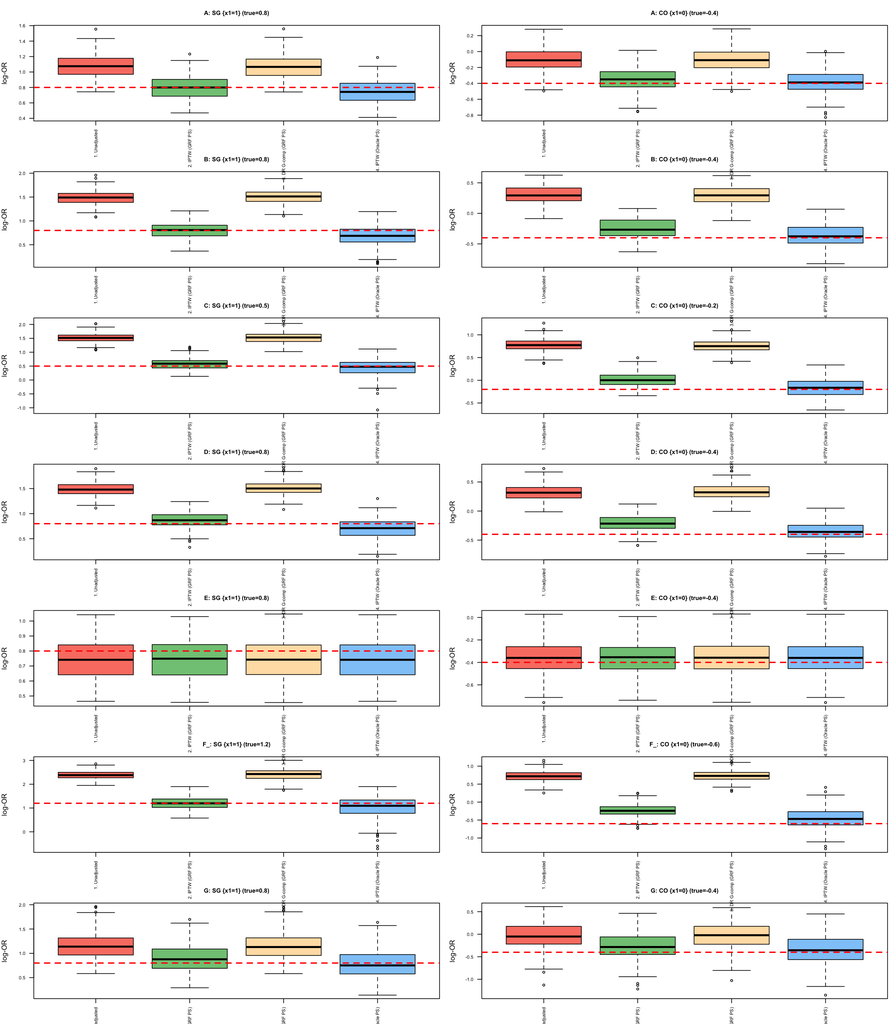

```r
par(mfrow = c(length(scenarios), 2), mar = c(3, 4, 3, 1))

box_cols <- c("salmon", "#81C784", "#FFE0B2", "#90CAF9")

for (sc_name in names(scenarios)) {
  sc_def <- scenarios[[sc_name]]
  res <- all_results[[sc_name]]

  boxplot(sg_est ~ method, data = res,
    main = paste0(sc_name, ": SG {x1=1} (true=",
                  sc_def$subgroup_effect, ")"),
    ylab = "log-OR", col = box_cols,
    cex.main = 0.85, las = 2, cex.axis = 0.65)
  abline(h = sc_def$subgroup_effect, col = "red", lwd = 2, lty = 2)

  boxplot(co_est ~ method, data = res,
    main = paste0(sc_name, ": CO {x1=0} (true=",
                  sc_def$complement_effect, ")"),
    ylab = "log-OR", col = box_cols,
    cex.main = 0.85, las = 2, cex.axis = 0.65)
  abline(h = sc_def$complement_effect, col = "red", lwd = 2, lty = 2)
}
```

# 5 Why DR G-Computation Fails in ForestSearch

## 5.1 Theoretical Explanation

The Bang & Robins (2005) DR estimator from Section 2.2 fits:

$$e(\Delta, V; \beta, \phi) = \Psi\bigl[s(\Delta, V; \beta) +
\phi \cdot \{f(\Delta \mid V; \hat\alpha)\}^{-1}\bigr]$$

The **doubly-robust property** holds because $\hat\mu_{dr}$ is consistent if either:

1. The PS model $\pi(V; \alpha)$ is correct, **OR**
2. The outcome regression $s(\Delta, V; \beta)$ is correct.

In ForestSearch, the outcome model within subgroup slices is intentionally `Y ~ treat` (no confounders), so condition (2) is never satisfied. When $s(\Delta, V; \beta) = \beta_0 + \beta_1 \Delta$ (no confounders), the IPS covariate $\phi \cdot \{f(\Delta \mid V; \hat\alpha)\}^{-1}$ alone cannot absorb the confounding because $\phi$ is a single scalar applied to a single covariate — it cannot adjust for the complex relationship between confounders and outcome.

**IPTW**, by contrast, does not require confounders in the outcome model. The weights directly create a pseudo-population where $W \perp X$, so even a simple `Y ~ treat` model yields a consistent estimate.

## 5.2 Empirical Demonstration

```r
set.seed(42)
n <- 5000
x1 <- rbinom(n, 1, 0.5)
x3 <- rnorm(n)
ps_true <- plogis(-0.5 + 1.5 * (0.6 * x1 + 0.8 * x3))
treat <- rbinom(n, 1, ps_true)
lp <- -1.0 + 0.5 * x3 + ifelse(x1 == 1, 0.8, -0.4) * treat
event <- rbinom(n, 1, plogis(lp))
df_demo <- data.frame(x1 = x1, x3 = x3, treat = treat, event = event)

ps_res <- estimate_propensity_scores(df_demo, "treat", c("x1", "x3"),
                                     method = "grf")
df_demo <- ps_res$data

fn_none <- make_effect_estimator("binary", "treat", "event",
  effect_measure = "OR", ps_adjust_method = "none")
fn_iptw <- make_effect_estimator("binary", "treat", "event",
  effect_measure = "OR", ps_adjust_method = "iptw")
fn_dr   <- make_effect_estimator("binary", "treat", "event",
  effect_measure = "OR", ps_adjust_method = "dr_gcomp")

sg <- df_demo[df_demo$x1 == 1, ]
co <- df_demo[df_demo$x1 == 0, ]

cat("=== N = 5000, strong confounding ===\n\n")
```

```
#> === N = 5000, strong confounding ===
```

```r
cat("Subgroup {x1=1} — true log-OR = 0.80:\n")
```

```
#> Subgroup {x1=1} — true log-OR = 0.80:
```

```r
cat(sprintf("  Unadjusted: %.3f (OR = %.2f)\n",
    fn_none(sg)$estimate, exp(fn_none(sg)$estimate)))
```

```
#>   Unadjusted: 1.324 (OR = 3.76)
```

```r
cat(sprintf("  IPTW:       %.3f (OR = %.2f)\n",
    fn_iptw(sg)$estimate, exp(fn_iptw(sg)$estimate)))
```

```
#>   IPTW:       0.889 (OR = 2.43)
```

```r
cat(sprintf("  DR G-comp:  %.3f (OR = %.2f)\n",
    fn_dr(sg)$estimate, exp(fn_dr(sg)$estimate)))
```

```
#>   DR G-comp:  1.334 (OR = 3.80)
```

```r
cat("\nComplement {x1=0} — true log-OR = -0.40:\n")
```

```
#>
#> Complement {x1=0} — true log-OR = -0.40:
```

```r
cat(sprintf("  Unadjusted: %.3f (OR = %.2f)\n",
    fn_none(co)$estimate, exp(fn_none(co)$estimate)))
```

```
#>   Unadjusted: 0.058 (OR = 1.06)
```

```r
cat(sprintf("  IPTW:       %.3f (OR = %.2f)\n",
    fn_iptw(co)$estimate, exp(fn_iptw(co)$estimate)))
```

```
#>   IPTW:       -0.345 (OR = 0.71)
```

```r
cat(sprintf("  DR G-comp:  %.3f (OR = %.2f)\n",
    fn_dr(co)$estimate, exp(fn_dr(co)$estimate)))
```

```
#>   DR G-comp:  -0.011 (OR = 0.99)
```

**ImportantKey Finding**

DR G-computation with a treatment-only outcome model (`Y ~ treat + ips_covar`, no confounders) performs **no better than unadjusted estimation** because the doubly-robust property requires confounders in the outcome model. IPTW correctly removes confounding bias because it operates through the weights, not the outcome model specification.

# 6 PS Quality Diagnostics

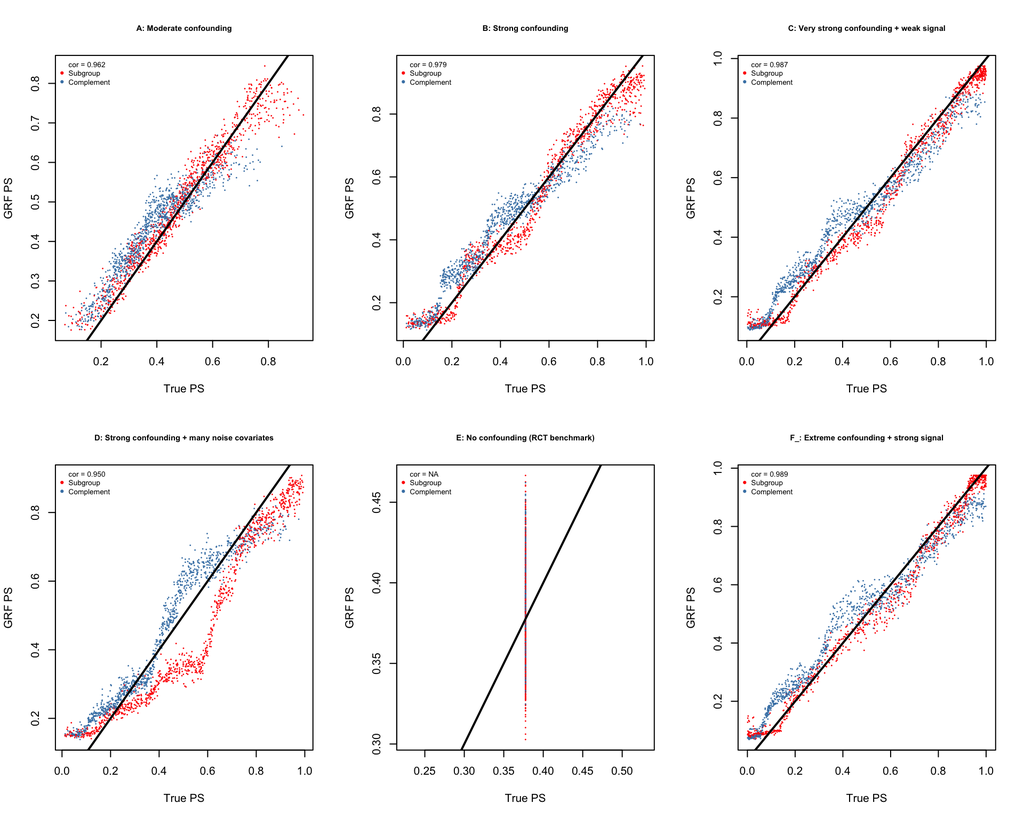

```r
par(mfrow = c(2, 3))

for (sc_name in c("A", "B", "C", "D", "E", "F_")) {
  sc_def <- scenarios[[sc_name]]
  df_s <- simulate_obs_study(
    n = 2000, seed = 42L,
    confounding_strength  = sc_def$confounding_strength,
    subgroup_effect       = sc_def$subgroup_effect,
    complement_effect     = sc_def$complement_effect,
    prognostic_strength   = sc_def$prognostic_strength,
    n_noise               = sc_def$n_noise
  )
  all_confs <- c(confs_sim, paste0("noise", seq_len(sc_def$n_noise)))
  ps_s <- estimate_propensity_scores(df_s, "treat", all_confs, method = "grf")

  plot(df_s$ps_true, ps_s$ps_hat, pch = 16, cex = 0.3,
       col = ifelse(df_s$in_sg, "red", "steelblue"),
       xlab = "True PS", ylab = "GRF PS",
       main = paste0(sc_name, ": ", sc_def$name),
       cex.main = 0.7)
  abline(0, 1, col = "black", lwd = 2)
  legend("topleft",
    legend = c(sprintf("cor = %.3f", cor(df_s$ps_true, ps_s$ps_hat)),
               "Subgroup", "Complement"),
    col = c(NA, "red", "steelblue"), pch = c(NA, 16, 16),
    cex = 0.65, bty = "n")
}
```

```r
par(mfrow = c(1, 1))
```

# 7 Weight Diagnostics

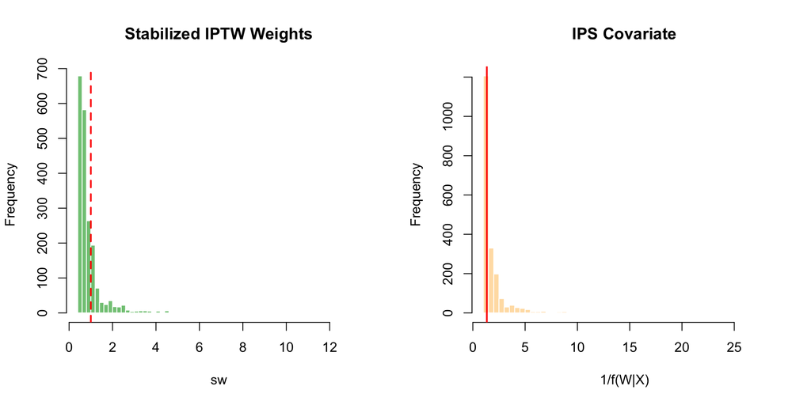

```r
df_strong <- simulate_obs_study(
  n = 2000, seed = 42L,
  confounding_strength = 2.5, prognostic_strength = 1.2,
  subgroup_effect = 1.2, complement_effect = -0.6, n_noise = 3
)
ps_strong <- estimate_propensity_scores(
  df_strong, "treat", c(confs_sim, paste0("noise", 1:3)), method = "grf")

par(mfrow = c(1, 2))
hist(ps_strong$sw, breaks = 50, col = "#81C784", border = "white",
     main = "Stabilized IPTW Weights", xlab = "sw")
abline(v = 1, col = "red", lwd = 2, lty = 2)
hist(ps_strong$ips_covar, breaks = 50, col = "#FFE0B2", border = "white",
     main = "IPS Covariate", xlab = "1/f(W|X)")
abline(v = median(ps_strong$ips_covar), col = "red", lwd = 2)
```

```r
par(mfrow = c(1, 1))

cat("Stabilized weights:  range [", round(range(ps_strong$sw), 2),
    "], mean =", round(mean(ps_strong$sw), 3), "\n")
```

```
#> Stabilized weights:  range [ 0.51 13.26 ], mean = 0.936
```

```r
cat("IPS covariate:       range [", round(range(ps_strong$ips_covar), 2),
    "], median =", round(median(ps_strong$ips_covar), 2), "\n")
```

```
#> IPS covariate:       range [ 1.03 27.83 ], median = 1.34
```

# 8 Key Principles

1. **IPTW is the recommended default** for observational data. It correctly removes confounding bias without requiring confounders in the outcome model, which aligns with ForestSearch’s treatment-only subgroup estimation architecture.
2. **DR G-computation is available but not recommended** in ForestSearch’s context. Without confounders in the outcome model, it loses its doubly-robust property and performs no better than unadjusted estimation.
3. **Full-sample PS, used as-is within subgroups.** Propensity scores are estimated once on the full `df.analysis`. The PS is a design quantity; re-estimating within slices would be incorrect.
4. **Bootstrap re-estimates PS from scratch** on each resampled dataset.
5. **PS trimming at [2.5%, 97.5%] before computing weights/IPS** prevents extreme values.
6. **GRF is the default PS estimator** for observational data: non-parametric, cross-fitted via OOB, already computed when `use_grf = TRUE`.

# 9 References

- Bang H, Robins JM (2005). “Doubly Robust Estimation in Missing Data and Causal Inference Models.” *Biometrics* 61(4): 962–972.
- Hernán MA, Robins JM (2020). *Causal Inference: What If*. Chapman & Hall/CRC. Chapter 12: IP Weighting and Marginal Structural Models.
- León LF, Jemielita T, Guo Z, Marceau West R, Anderson KM (2024). “Exploratory subgroup identification in the heterogeneous Cox model.” *Statistics in Medicine*. DOI: 10.1002/sim.10163.
- Athey S, Tibshirani J, Wager S (2019). “Generalized Random Forests.” *Annals of Statistics* 47(2): 1148–1178.
- Robins JM, Rotnitzky A, Zhao LP (1994). “Estimation of Regression Coefficients When Some Regressors Are Not Always Observed.” *JASA* 89(427): 846–866.
- Lunceford JK, Davidian M (2004). “Stratification and weighting via the propensity score in estimation of causal treatment effects: A comparative study.” *Statistics in Medicine* 23: 2937–2960.
- Funk MJ, Westreich D, Wiesen C, Stürmer T, Brookhart MA, Davidian M (2011). “Doubly Robust Estimation of Causal Effects.” *Am J Epidemiol* 173(7): 761–767.